# W3cubDocs

/Matplotlib 3.5

# matplotlib.pyplot.colorbar

**matplotlib.pyplot.colorbar(*mappable=None*, *cax=None*, *ax=None*, **kw)[[source]](https://github.com/matplotlib/matplotlib/blob/v3.5.1/lib/matplotlib/pyplot.py#L2079-L2089)**

Add a colorbar to a plot.

**Parameters**

**mappable**

The `matplotlib.cm.ScalarMappable` (i.e., `AxesImage`, `ContourSet`, etc.) described by this colorbar. This argument is mandatory for the `Figure.colorbar` method but optional for the `pyplot.colorbar` function, which sets the default to the current image.

Note that one can create a `ScalarMappable` "on-the-fly" to generate colorbars not attached to a previously drawn artist, e.g.

```
fig.colorbar(cm.ScalarMappable(norm=norm, cmap=cmap), ax=ax)
```

**cax**`Axes`, optional**

Axes into which the colorbar will be drawn.

**ax**`Axes`, list of Axes, optional**

One or more parent axes from which space for a new colorbar axes will be stolen, if *cax* is None. This has no effect if *cax* is set.

**use_gridspec**bool, optional**

If *cax* is `None`, a new *cax* is created as an instance of Axes. If *ax* is an instance of Subplot and *use_gridspec* is `True`, *cax* is created as an instance of Subplot using the `gridspec` module.

**Returns**

**colorbar**`Colorbar`**

#### Notes

Additional keyword arguments are of two kinds:

axes properties:

**locationNone or {'left', 'right', 'top', 'bottom'}**

The location, relative to the parent axes, where the colorbar axes is created. It also determines the *orientation* of the colorbar (colorbars on the left and right are vertical, colorbars at the top and bottom are horizontal). If None, the location will come from the *orientation* if it is set (vertical colorbars on the right, horizontal ones at the bottom), or default to 'right' if *orientation* is unset.

**orientationNone or {'vertical', 'horizontal'}**

The orientation of the colorbar. It is preferable to set the *location* of the colorbar, as that also determines the *orientation*; passing incompatible values for *location* and *orientation* raises an exception.

**fractionfloat, default: 0.15**

Fraction of original axes to use for colorbar.

**shrinkfloat, default: 1.0**

Fraction by which to multiply the size of the colorbar.

**aspectfloat, default: 20**

Ratio of long to short dimensions.

**padfloat, default: 0.05 if vertical, 0.15 if horizontal**

Fraction of original axes between colorbar and new image axes.

**anchor(float, float), optional**

The anchor point of the colorbar axes. Defaults to (0.0, 0.5) if vertical; (0.5, 1.0) if horizontal.

**panchor(float, float), or *False*, optional**

The anchor point of the colorbar parent axes. If *False*, the parent axes' anchor will be unchanged. Defaults to (1.0, 0.5) if vertical; (0.5, 0.0) if horizontal.

colorbar properties:

[output not shown]

The following will probably be useful only in the context of indexed colors (that is, when the mappable has norm=NoNorm()), or other unusual circumstances.

[output not shown]

If *mappable* is a `ContourSet`, its *extend* kwarg is included automatically.

The *shrink* kwarg provides a simple way to scale the colorbar with respect to the axes. Note that if *cax* is specified, it determines the size of the colorbar and *shrink* and *aspect* kwargs are ignored.

For more precise control, you can manually specify the positions of the axes objects in which the mappable and the colorbar are drawn. In this case, do not use any of the axes properties kwargs.

It is known that some vector graphics viewers (svg and pdf) renders white gaps between segments of the colorbar. This is due to bugs in the viewers, not Matplotlib. As a workaround, the colorbar can be rendered with overlapping segments:

```
cbar = colorbar()
cbar.solids.set_edgecolor("face")
draw()
```

However this has negative consequences in other circumstances, e.g. with semi-transparent images (alpha < 1) and colorbar extensions; therefore, this workaround is not used by default (see issue #1188).

## Examples using `matplotlib.pyplot.colorbar`

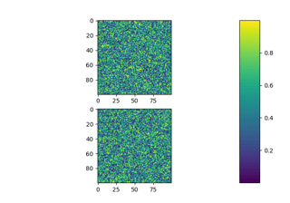

[Subplots spacings and margins](https://matplotlib.org/3.5.1/gallery/subplots_axes_and_figures/subplots_adjust.html#sphx-glr-gallery-subplots-axes-and-figures-subplots-adjust-py)

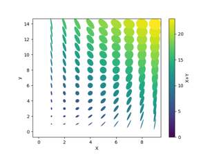

[Ellipse Collection](https://matplotlib.org/3.5.1/gallery/shapes_and_collections/ellipse_collection.html#sphx-glr-gallery-shapes-and-collections-ellipse-collection-py)

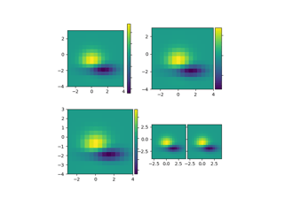

[Axes Divider](https://matplotlib.org/3.5.1/gallery/axes_grid1/demo_axes_divider.html#sphx-glr-gallery-axes-grid1-demo-axes-divider-py)

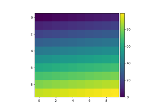

[Simple Colorbar](https://matplotlib.org/3.5.1/gallery/axes_grid1/simple_colorbar.html#sphx-glr-gallery-axes-grid1-simple-colorbar-py)

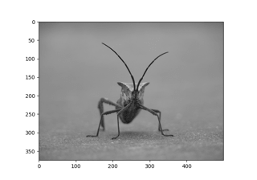

[Image tutorial](https://matplotlib.org/3.5.1/tutorials/introductory/images.html#sphx-glr-tutorials-introductory-images-py)

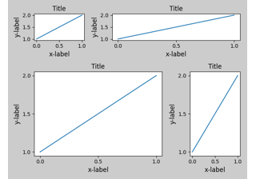

[Tight Layout guide](https://matplotlib.org/3.5.1/tutorials/intermediate/tight_layout_guide.html#sphx-glr-tutorials-intermediate-tight-layout-guide-py)

© 2012–2021 Matplotlib Development Team. All rights reserved.  
Licensed under the Matplotlib License Agreement.  
https://matplotlib.org/3.5.1/api/_as_gen/matplotlib.pyplot.colorbar.html